# R Notebook

```r
library("dplyr")
library("ggplot2")
bbdd <- read.csv("D:/calificaciones_cervezas/beer_reviews.csv")
```

```r
library("modeest")
# Distinct: generarmos una que incluya todas las combinaciones cervezas, tipos y cervecerias dejando un unico registro por combinacion identificada
tabla_cervezas <- distinct(bbdd, id_cerveceria, nombre_cerveceria, tipo_cerveza, nombre_cerveza, id_cerveza )
# group_by y summarise: calculan la mediana del campo grado_alcohol para cada ID de cerveza
# left_join : me permite incoporar a la tabla de estadisticas la informacion del nombre nombre de la cerveceria, id de la cerveria y nombre de la cerveza
stats_cervezas <- group_by( bbdd, id_cerveza) %>% summarise(grados_alcohol = median(grado_alcohol, na.rm = TRUE))%>% left_join( tabla_cervezas, by = "id_cerveza")
```

Teniendo la informacion de cada cerveza debemos consolidar la informacion de cada cerveceria ( nombre y id ) y calcular las estadisticas asociadas a sus productos y los grados de alchol ( promedio , cuartil 1, mediana y cuartil 3)

```r
# Distinct: generarmos una que incluya todas las combinaciones id_cerveria y nombre_cerveria, dejando un unico registro por combinacion.
tabla_cervecerias <- distinct(bbdd, id_cerveceria, nombre_cerveceria)
# group_by y summarise: calculan las estadisticas de promedio , cuartil 1, cuartil 2 y cuartil 3 en funcion del campo grados de alcohol para cada ID de cerveza
# Filter : eliminamos los registros de cervecerias para los cuales no se pudo calcular el promedio de grados de alcohol
# Arrange : organizamos la tabla en funcion en orden descendente y en funcion del campo cuartil 3.
#left_join : me permite incoporar a la tabla de estadisticas la informacion del nombre de la cerveceria.
stats_cervecerias <- group_by(stats_cervezas, id_cerveceria) %>% summarise(  prom_alcohol = mean(grados_alcohol , na.rm = TRUE), Q1 = quantile(grados_alcohol, prob = 0.25 , na.rm=TRUE), Q2 = quantile(grados_alcohol, prob = 0.5 , na.rm=TRUE), Q3 = quantile(grados_alcohol, prob = 0.75 , na.rm=TRUE) ) %>% filter(!is.infinite(prom_alcohol))%>% arrange(desc(Q3))%>% left_join( tabla_cervecerias, by = "id_cerveceria")
#Creamos una tabla que me capture las primeras 5 observaciones.
top5_cervecerias <- top_n(stats_cervecerias,5,prom_alcohol )
```

Para poder compartir esta información al equipo de marketing podriamos construir un boxplot para las primeras 5 obseraciones de la tabla. Esto nos va a permitir mostrar graficamente las distribucion en cuanto a grados de alcohol que presentan las cervezas de estas cervecerias.

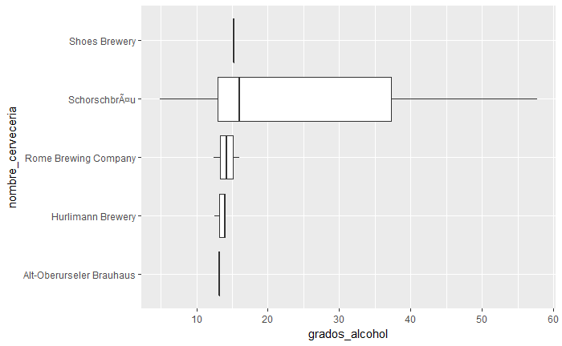

```r
top5_detalle_cervezas <- semi_join(stats_cervezas, top5_cervecerias , by = "id_cerveceria") %>% filter(!is.na(grados_alcohol))
top5_cajas <- ggplot(top5_detalle_cervezas, aes(nombre_cerveceria, grados_alcohol)) + geom_boxplot()+ coord_flip()
top5_cajas
```

………………………………………………………………………………………………… SEGUNDO PUNTO …………………………………………………………………………………………………

La idea es recomendar las cervezas que tengan la mejor puntuacion por diferentes usuarios. Para esto debemos debemos iniciar construyendo una tabla con la calificacion promedio que cada usuario le ha asignado a cada cerveza para que cada usuario represente una unico registro de calificacion independientemente del numero de veces que ha calificado la misma cerveza.

```r
# Distinct: generarmos una que incluya todas las combinaciones de usuarios y cervezas calificadas
# Mutate : me aryuda a asignarle a  cada combinacion de usuario y cerveza calificada un unico ID
tabla_calificaciones_cervezas_usuarios<- distinct(bbdd, usuario, nombre_cerveza ,id_cerveza)%>% mutate(id_calificacion = paste(usuario,c(id_cerveza), sep ="-"))
# Mutate: me aryuda a generar en la base de datos un ID unico para cada combinacion de usuario y cerveza calificada
# group_by y summarise: calculan las estadisticas de cada combinacion de usuario y cerveza calificada en funcion de la calificaciones de los usuarios
# left_join : me permite incoporar a la tabla de estadisticas la informacion del nombre del nombre de la cerveza y id de la cerveza
stats_calificacion_usuario <- mutate(bbdd, id_calificacion =paste(usuario, c(id_cerveza), sep ="-"))%>% group_by( id_calificacion) %>% summarise( calificacion_prom_u = mean(calificacion_total, na.rm = TRUE), calificacion_med_u = median(calificacion_total, na.rm = TRUE), calificacion_desv_u = sd(calificacion_total, na.rm = TRUE), sabor_prom_u = mean(calificacion_sabor, na.rm = TRUE), aroma_prom_u = mean(calificacion_aroma, na.rm = TRUE), paleta_prom_u = mean(calificacion_paleta, na.rm = TRUE), apariencia_prom_u = mean(calificacion_apariencia, na.rm = TRUE))%>% left_join( tabla_calificaciones_cervezas_usuarios, by = "id_calificacion")
stats_calificacion_usuario
```

| id_calificacion | calificacion_prom_u | calificacion_med_u | calificacion_desv_u | sabor_prom_u | aroma_prom_u | paleta_prom_u | apariencia_prom_u | usuario | nombre_cerveza | id_cerveza |
| --- | --- | --- | --- | --- | --- | --- | --- | --- | --- | --- |
| -10 | 4.00 | 4.00 | NaN | 4.00 | 3.50 | 4.50 | 5.00 |  | Allagash Dubbel Ale | 10 |
| -1005 | 3.75 | 3.75 | 0.3535534 | 4.25 | 4.00 | 4.25 | 4.00 |  | HopDevil Ale | 1005 |
| -10055 | 2.50 | 2.50 | NaN | 2.50 | 3.50 | 2.00 | 4.00 |  | Buckleys Bitter Ale | 10055 |
| -10056 | 3.00 | 3.00 | NaN | 3.00 | 3.00 | 3.50 | 3.00 |  | Buckleys Original Ale | 10056 |
| -10057 | 3.00 | 3.00 | NaN | 2.50 | 3.00 | 2.00 | 4.50 |  | Buckleys Pilz | 10057 |
| -10060 | 4.00 | 4.00 | NaN | 3.50 | 3.00 | 4.00 | 3.00 |  | Jamieson Brown Ale | 10060 |
| -10061 | 3.50 | 3.50 | NaN | 3.50 | 3.50 | 3.50 | 3.00 |  | Jamieson Mountain Ale | 10061 |
| -1010 | 4.50 | 4.50 | NaN | 4.00 | 4.00 | 4.50 | 4.00 |  | Prima Pils | 1010 |
| -1013 | 3.50 | 3.50 | NaN | 4.00 | 3.50 | 4.00 | 3.50 |  | Storm King Stout | 1013 |
| -10228 | 3.50 | 3.50 | NaN | 3.00 | 3.50 | 4.00 | 4.00 |  | 3 Ravens Black | 10228 |

[output cut: 990 more lines]

Con la informacion de la calificacion que cada usuario ha asignado en promedio a cada cerveza procedemos a calcular las estadisticas para cada producto ( estadisticas sobre el numero de observaciones o calificaciones recibidas por usuarios diferentes, la calificacion total y la calificacion que en promedio a recibido los items de sabor , aroma , paleta y apariencia).

La idea es recomendar las cervezas que tengan la mejor calificacion promedio , con la menor variabilidad posible (para poder garantizar que en el peor de los escenarios la calificacion que le otorguen nuevos usuario no se aleje demasiado del promedio) y un numero razonable de observaciones ( se excluyen cervezas que no tengan con por lo menos 30 calificaciones).

Para combinar todos estos elementos el ranking de cervezas se puede calcular el limite inferior que tendria la calificacion de cada cerveza ( esto nos permite incorporar en la evaluacion : la calificacion promedio , la desviacion estandar , el numero de observaciones y un nivel de confianza de aproximadamente el 95%).

```r
#El cuantil lo utilizaremos para calcular el limite inferior y superior de la calificacion.
cuantil<- qnorm(1 - 0.05/2)
# group_by y summarise: calculan las estadisticas de cada cerveza en funcion de la calificaciones de los usuarios
# left_join : me permite incoporar a la tabla de estadisticas la informacion del nombre de la cerveza para facilitar la interpretacion de los resultados
# filter : me ayuda a eliminar las desviaciones estandar con valores infinitos y no calculados y cervezas con menos de 30 observaciones
#mutate me ayuda a calcular el limite inferior y superior que puede tener la calificacion de cada cerveza
calificaciones_cervezas <- group_by(stats_calificacion_usuario, id_cerveza) %>% summarise( n=n()-sum(is.na(calificacion_prom_u)),calificacion_prom = mean(calificacion_prom_u, na.rm = TRUE), calificacion_med = median(calificacion_prom_u, na.rm = TRUE), calificacion_desv = sd(calificacion_prom_u, na.rm = TRUE), sabor_prom = mean(sabor_prom_u, na.rm = TRUE), aroma_prom = mean(aroma_prom_u, na.rm = TRUE), paleta_prom = mean(paleta_prom_u, na.rm = TRUE), apariencia_prom = mean(apariencia_prom_u, na.rm = TRUE))%>% left_join(stats_cervezas, by = "id_cerveza")%>% filter((is.finite(calificacion_desv)| is.nan(calificacion_desv)) & n>30) %>% mutate(limINF_calificacion = calificacion_prom - (cuantil*calificacion_desv / sqrt(n) ), limSUP_calificacion = calificacion_prom + (cuantil*calificacion_desv / sqrt(n) )) %>% arrange( desc(limINF_calificacion), desc(calificacion_prom) , limSUP_calificacion , calificacion_desv, desc(n))
#Mostramos el TOP3 de cervezas con mayor limite inferior
head(select(calificaciones_cervezas, nombre_cerveza, id_cerveza, n , limINF_calificacion, calificacion_prom, limSUP_calificacion, calificacion_desv),n=3)
```

| nombre_cerveza | id_cerveza | n | limINF_calificacion | calificacion_prom | limSUP_calificacion | calificacion_desv |
| --- | --- | --- | --- | --- | --- | --- |
| Rare D.O.S. | 63649 | 33 | 4.758167 | 4.848485 | 4.938803 | 0.2647183 |
| Dirty Horse | 44910 | 39 | 4.728820 | 4.820513 | 4.912206 | 0.2921603 |
| Southampton Berliner Weisse | 8626 | 41 | 4.677120 | 4.768293 | 4.859466 | 0.2978582 |

Al momento de presentar los resultados al equipo de Marketing podemos explicar que para la seleccion de las cervezas hemos utilizar un indicador que nos permita incluir los siguientes aspectos (los que estan en parentesis no van dirigidos al equipo de MKT) :

[output not shown]

Estos tres criterios mencionados han sido incorporados en un indicador que representaria el peor escenario para la calificacion y hemos optado por seleccionar las cervezas que aun en el peor escenario tendrian las mejores calificaciones, en este caso:

```
     1.  Rare D.O.S. (63649) - 4,76
     2.  Dirty Horse (44910) - 4,73
     3.  Southampton Berliner Weisse (8626) - 4,67
```

………………………………………………………………………………………………… TERCER PUNTO …………………………………………………………………………………………………

```r
 library("FactoMineR")
library("factoextra")
library("ggcorrplot")
```

```r
#Generamos una tabla con los aspectos a analizar ( calificaciones )
 base_pca <-  filter( bbdd, !is.na(calificacion_aroma) & !is.na(calificacion_apariencia) & !is.na(calificacion_paleta) & !is.na(calificacion_sabor) & !is.na(calificacion_total)) %>% select(calificacion_aroma, calificacion_apariencia, calificacion_paleta , calificacion_sabor, calificacion_total, tipo_cerveza)
base_pca
```

| calificacion_aroma | calificacion_apariencia | calificacion_paleta | calificacion_sabor | calificacion_total | tipo_cerveza |
| --- | --- | --- | --- | --- | --- |
| 2.0 | 2.5 | 1.5 | 1.5 | 1.5 | Hefeweizen |
| 2.5 | 3.0 | 3.0 | 3.0 | 3.0 | English Strong Ale |
| 2.5 | 3.0 | 3.0 | 3.0 | 3.0 | Foreign / Export Stout |
| 3.0 | 3.5 | 2.5 | 3.0 | 3.0 | German Pilsener |
| 4.5 | 4.0 | 4.0 | 4.5 | 4.0 | American Double / Imperial IPA |
| 3.5 | 3.5 | 3.0 | 3.5 | 3.0 | Herbed / Spiced Beer |
| 3.5 | 3.5 | 4.0 | 4.0 | 3.5 | Herbed / Spiced Beer |
| 2.5 | 3.5 | 2.0 | 3.5 | 3.0 | Herbed / Spiced Beer |
| 3.0 | 3.5 | 3.5 | 4.0 | 4.0 | Herbed / Spiced Beer |
| 3.5 | 5.0 | 4.0 | 4.0 | 4.5 | Herbed / Spiced Beer |

[output cut: 990 more lines]

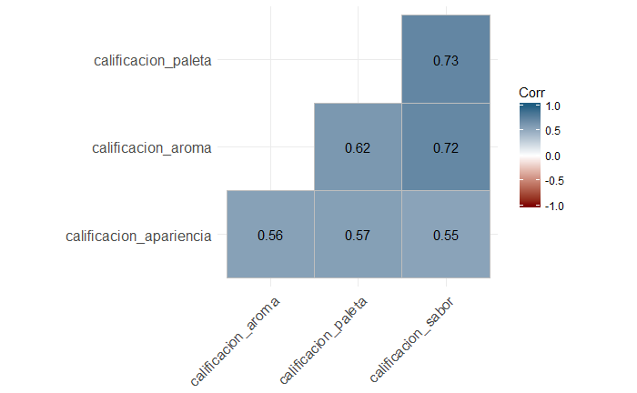

```r
#calculamos las correlaciones en las variables para validar que estas no esten correlacionadas entre si
correlaciones <- round(cor(select(base_pca, -calificacion_total,-tipo_cerveza)),2)
#este codigo me permite prepresentar graficamente la matriz de correlaciones.
ggcorrplot(correlaciones, hc.order = TRUE, type = "lower",lab = TRUE, insig= "blank",colors = c("#7f0000", "white", "#205e82"))
```

De acuerdo con la matriz anterior existe una alta correlacion entre las diferentes calificaciones que podrian determinar la calidad de la cerveza ( por ejemplo entre aroma y sabor hay una correlacion de 0.72 y entre paleta y sabor 0.73) por este motivo se requiere la realizacion de un analisis de componentes principales para determinar que variables contribuyen en mayor medida a explicar la variabilidad que presenta la calificacion total.

Dado que la desviacion estandar y la media de estas variables puede ser diferente debemos normalizarlas antes de llevar a cabo el analisis.

```r
#calculo para componentes principales , en donde la columna 5 es la variable que buscamos explicar en funcion de los componentes principales.
pca <- PCA( base_pca, scale.unit = TRUE, ncp = 3, quanti.sup = 5,quali.sup= 6,  graph = FALSE)
#visualizar el porcentaje de varianza que es explicado por las componentes
pca$eig
```

|  | eigenvalue | percentage of variance | cumulative percentage of variance |
| --- | --- | --- | --- |
| comp 1 | 2.8772927 | 71.932317 | 71.93232 |
| comp 2 | 0.5066244 | 12.665611 | 84.59793 |
| comp 3 | 0.3836650 | 9.591626 | 94.18955 |
| comp 4 | 0.2324179 | 5.810447 | 100.00000 |

Al validar los 4 componentes se puede validar que el primer componente explica cerca del 72% de la variabilidad , el segundo componente 12,6 %.

```r
var <- get_pca_var(pca)
var$cor
```

```
                            Dim.1      Dim.2        Dim.3
calificacion_aroma      0.8563247 -0.1433136  0.457207488
calificacion_apariencia 0.7764340  0.6279203 -0.008027911
calificacion_paleta     0.8642755 -0.1516228 -0.416863174
calificacion_sabor      0.8911671 -0.2623209 -0.028053413
```

en la tabla anterior podemos ver que el primer componente las variables que mas aportan son sabor, paleta y aroma. Esto implicaria que valores elevados de este componente corresponden a cervezas que han obtenido buenas calificaciones en los mismos. para el segundo componente se resalta que la mayor aportacion es generada por apariencia y el resto variables presentan signos negativos , lo que nos llevaria a asumir que valores elevados en esta segunda componente corresponden a cervezas que tienen una calificacion muy alta en terminos de apariencia pero baja en sabor , aroma y paleta.

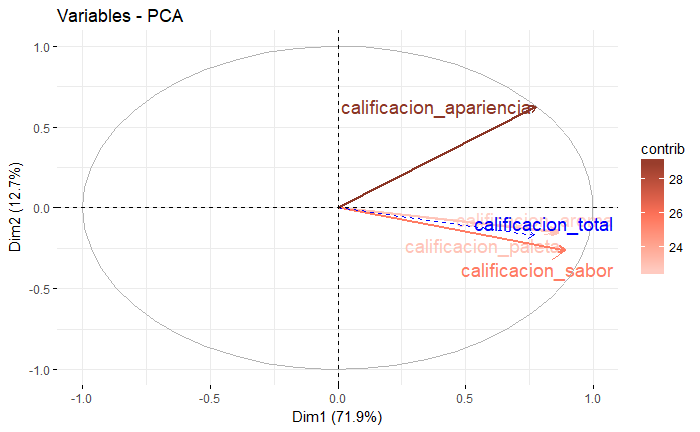

```r
fviz_pca_var(pca, col.var = "contrib",gradient.cols = c("#ffd0c7", "#ff7259", "#8b3626"), repel = TRUE, arrowsize = 1 , labelsize = 5)
```

De acuerdo con esta grafica las variables que contribuyen más a explicar la variabilidad en la calidad de una cerveza o su calificación total son la apariencia y el sabor (teniendo mayor contribucion la apariencia).

………………………………………………………………………………………………… CUARTO PUNTO …………………………………………………………………………………………………

```r
# Distinct: generarmos una tabla que incluya todas las combinaciones cervezas y tipos de cerveza dejando un unico registro por combinacion identificada
tabla_tipos_y_cervezas <- distinct(bbdd, tipo_cerveza, nombre_cerveza, id_cerveza )
#El cuantil lo utilizaremos para calcular el limite inferior y superior de la calificacion.
cuantil<- qnorm(1 - 0.05/2)
# Select : Vamos a partir de la tabla "stats_calificacion_usuario" que se construyo en el segundo punto para calcular las calificaciones promedio que cada tipo de cerveza ha recibido ( cada observacion utilizada para el promedio corresponde a una combinacion de usuario y cerveza ) adicionalmente nos vamos a concentrar unicamente en las variables de aroma y apariencia.
# Mutate: vamos a crear un nuevo campo en las estadisticas de usuario que me promedie la calificacion promedio que el usuario le dio a los items de aroma y apariencia.
# Left_join : vamos a unir la tabla de calificaciones con la tabla de tipos y cervezas para recuparar la informacion asociada al tipo de cerveza que calificó cada usuario.
# group_by y summarise: calculan las estadisticas de promedio y desviacion para el campo que promedia el aroma y la apariencia.
# filter : me ayuda a eliminar las desviaciones estandar con valores infinitos y no calculados y cervezas con menos de 5 observaciones
#mutate me ayuda a calcular el limite inferior para la calificacion de aroma y apariencia.
# Arrange : me ordena la tabla en orden descendente en funcion del limite inferior.
stats_calificacion_tipo_cerveza <- select(stats_calificacion_usuario, nombre_cerveza, id_cerveza, aroma_prom_u, paleta_prom_u ) %>% mutate(aroma_y_apariencia = (aroma_prom_u +paleta_prom_u)/2) %>% left_join( tabla_tipos_y_cervezas, by = c("id_cerveza")) %>% group_by(tipo_cerveza) %>% summarise( n=n()-sum(is.na(aroma_y_apariencia)), aroma_y_apariencia_prom = mean(aroma_y_apariencia, na.rm = TRUE), aroma_y_apariencia_desv= sd(aroma_y_apariencia, na.rm = TRUE)) %>% filter((is.finite(aroma_y_apariencia_desv)| is.nan(aroma_y_apariencia_desv)) & n>5) %>% mutate( limINF_aroma_apariencia = aroma_y_apariencia_prom - (cuantil*aroma_y_apariencia_desv / sqrt(n) )) %>% arrange( desc(limINF_aroma_apariencia), desc(aroma_y_apariencia_prom))
top10_tipos_aroma_apariencia <- top_n(stats_calificacion_tipo_cerveza, n=10, limINF_aroma_apariencia)
top10_tipos_aroma_apariencia
```

| tipo_cerveza | n | aroma_y_apariencia_prom | aroma_y_apariencia_desv | limINF_aroma_apariencia |
| --- | --- | --- | --- | --- |
| American Double / Imperial Stout | 50151 | 4.127173 | 0.5124226 | 4.122688 |
| Quadrupel (Quad) | 17995 | 4.128508 | 0.4941503 | 4.121288 |
| Eisbock | 2651 | 4.134100 | 0.4550227 | 4.116779 |
| Russian Imperial Stout | 53555 | 4.079891 | 0.4980831 | 4.075673 |
| American Wild Ale | 17638 | 4.081824 | 0.4947988 | 4.074522 |
| Gueuze | 5982 | 4.081474 | 0.4964809 | 4.068892 |
| American Double / Imperial IPA | 84686 | 4.057772 | 0.4777691 | 4.054554 |
| Lambic - Unblended | 1109 | 4.040577 | 0.4941721 | 4.011493 |
| Weizenbock | 9351 | 4.016603 | 0.4510961 | 4.007460 |
| American Barleywine | 26501 | 4.006780 | 0.4568950 | 4.001279 |

```
1. American Double / Imperial Stout .
```

………………………………………………………………………………………………… QUINTO PUNTO …………………………………………………………………………………………………

Para la realizacion del ultimo punto comenzaremos definiendo una funcion que recibe 4 parametros que representan el peso o importancia que tiene el sabor, el aroma , la paleta y la apariencia de una cerveza.

```
     1. Ningun parametro tener un peso superior al 100%
     2. Ningun parametro puede tener un peso negativo.
     3. Los cuatro parametros en conjunto deben representar el 100%.
```

Validados los tres casos la función lleva ejecuta un modelo de optimizacion lineal que busca recomendarle al cliente una cerveza que logre maximizar su experiencia en funcion de los items que más valor respresentan para el usuario ( pesos de las caracterizticas) y las calificaciones que en promedio se han registrado para cada tipo de cerveza.

-Peso(k) representa el peso que otorga el usuario al criterio “k”( aroma, sabor , paleta y apariencia) -Calificacion_promedio(k ,i) representa la calificacion promedio que tiene el criterio “k” en la cerveza “i” -X(i) representa una variable binaria que toma el valor de 1 si se recomienda la cereza “i” y 0 dlc.

Sujeto a las siguientes restricciones

```
     1. Se tiene que seleccionar 1 unica cerveza lo cual se modelara a partir de dos restricciones
                  sumatoria(i)  X(i) > = 1    y   sumatoria(i)  X(i) <= 1
```

```r
recomendar_cerveza <- function(sabor,aroma, paleta , apariencia)
{
  #Asignamos cada parametro recibido por la funcion a variables locales
  peso_sabor <- sabor
  peso_aroma <- aroma
  peso_paleta <- paleta
  peso_apariencia <- apariencia

  #Validamos que los parametros recibidos por la funcion sean adecuados.

  if( peso_sabor > 1 | peso_aroma > 1 | peso_paleta >1 | peso_apariencia> 1)
    { return("No pueden definirse pesos superiores a uno . PESO(i) <= 1")}

  else-if( peso_sabor < 0 | peso_aroma < 0 | peso_paleta < 0 | peso_apariencia < 0)
    { return("No pueden definirse pesos negativos , PESO(i) >= 0")}

  else-if( peso_sabor + peso_aroma + peso_paleta + peso_apariencia > 1| peso_sabor + peso_aroma + peso_paleta + peso_apariencia < 1)
   { return("La suma de los pesos no puede ser superior/inferior a 1, sum (PESO(i)) == 1")}

  else
  {
      library("lpSolve")

      #definimos el vector con los costos de la funcion objetivo
      calificaciones_ponderadas <- as.vector(calificaciones_cervezas$sabor_prom * peso_sabor +  calificaciones_cervezas$paleta_prom * peso_aroma + calificaciones_cervezas$paleta_prom * peso_paleta + calificaciones_cervezas$apariencia_prom * peso_apariencia )

      #definimos el vector que contiene los valores del lado derecho de las restricciones
      restricciones = c(1,1)
      #definimos el vector que indica que signos tienen las restricciones
      signos = c(">=","<=")
      #Definimos una matriz de unos con una dimension de 2 x numero cervezas ,
      matriz_restricciones = matrix(1, 2, length(calificaciones_ponderadas))

      #corremos el modelo de optimizacion indicando los parametros requeridos e indicando
      #que en el modelo todas las variables seran binarias.
      opti <- lp("max", calificaciones_ponderadas, matriz_restricciones , signos, restricciones, all.bin = TRUE)

       return(opti)
    }
}
```

Definimos una funcion que me permita identificar la cerveza que es seleccionada por el modelo de optimizacion para poder informar el nombre de la misma.

Esta funcion recibe como parametro el vector con todas las variables del modelo de optimizacion y la funcion se encargara de recorrer el vector hasta que logre identificar la variable que fue seleccionada por el modelo ( aquella que tenga valor == 1) Cuando logra identificar que variable es la seleccionada, utilizará el indice de la variable para buscar su nombre en la tabla calificaciones_cervezas.

```r
identificar_cerveza <- function(vector_variables)
{
  #asignamos el vector a una variable local
  variables <- vector_variables
  #inicializamos el contador para iniciar el loop
  i <- 0
  cerveza <- "No identificado"

   while(i <= length(variables)  )
  {
    i <- i + 1
    temp <- variables[i]
    if(temp >= 1 ){ break } #si logra identificar la variable con valor == 1, termina el loop
  }
  if( i >= 1 & i <= length(variables) ){cerveza <- calificaciones_cervezas$nombre_cerveza[i]}
  return(cerveza)
}
```

` En la siguiente linea se deben definir los valores que se pasaran al modelo para recomendar una cerveza y se llamara a la funcion “recomendar_cerveza”

```r
#se definen los pesos para cada criterio
aroma <- 0.0
sabor <- 0.0
paleta <- 0.0
apariencia <- 1
# se llama a la funcion recomendar_Cerveza informando los pesos
resultado_opti <- recomendar_cerveza( aroma, sabor, paleta, apariencia)
# se imprime el resultado de la funcion objetivo
resultado_opti$objval
```

```
[1] 4.643548
```

Dado que ya se tiene un resultado para la funcion objetivo, se debe identificar cual fue la cerveza seleccionada por el modelo para poder informar al usuario. Para esto se llamara a la funcion “identificar_cereza” y se le entregara como parametro el vector con todas las variables solucion del modelo.

```r
variables <- resultado_opti$solution
#se llama a la funcion identificar_Cerveza
resultado_cerveza <- identificar_cerveza(variables)
#se imprime el nombre de la cerveza seleccionada
print(paste("Se recomienda la cerveza : ", resultado_cerveza))
```

```
[1] "Se recomienda la cerveza :  Cantillon BlÃ¥bÃ¦r Lambik"
```